**City College of San Francisco**

MATH 108 - Foundations of Data Science

# Lecture 01: Introduction

Associated Textbook Sections: [1.0, 1.1, 1.2, 1.3](https://inferentialthinking.com/chapters/01/what-is-data-science.html)

## Overview

- What is Data Science?
- Jupyter Notebooks
- Analyzing Stories
- Exploring a Relationship

## What is Data Science?

Learning about the world from data using computation:

- Exploration
  - Identifying patterns in data
  - Uses visualizations
- Inference
  - Using data to draw reliable conclusions about the group the data originated from
  - Uses statistics
- Prediction
  - Making informed guesses about unobserved data
  - Uses machine learning

## Jupyter Notebooks

- Jupyter notebooks are web applications
- Some things you can do with notebooks:
  - develop and run computer-interpreted code
  - engage with and produce human-focused documentation
  - support reproducible science
  - and more!

### Notebook Cells

You'll learn a lot about notebooks throughout the semester, but the main building block of a notebook is called a cell.

There are two basic types of cells:

- Code cells
- Markdown (text) cells

#### A Code Cell

```python
# This is a code cell that prints out the text Hello, MATH 108!

print('Hello, MATH 108!')
```

```
Hello, MATH 108!
```

#### A Markdown Cell

- All the formated text is contained in a Markdown cell.
- You can double click these cells to edit them.
- Markdown is a markup language that allows you to type as if you were using a basic text editor, but you have a few formatting features such as:
  - **bold**,
  - *italic*,
  - etc.
- There is a straightforward [Markdown guide](https://www.markdownguide.org/basic-syntax/) that shows you have to do all the basic formatting.

## Analyzing Stories

### Importing Tools

The following code contains things I'll use to run this demonstration. You don't have to understand how this works or change it for now.

```python
# The typical setup for the notebooks in this course
from datascience import *
import numpy as np
import matplotlib.pyplot as plots
plots.style.use('fivethirtyeight')
%matplotlib inline
```

### Python "Reads" Two Books

Load the public domain text from the Adventures of Huckleberry Finn and Little Women from [Project Gutenberg](https://www.gutenberg.org/)

```python
with open("./data/huck_finn.txt") as huck_finn, \
     open("./data/little_women.txt") as little_women:

    huck_finn_text = huck_finn.read()
    huck_finn_chapters = huck_finn_text.split('CHAPTER ')[44:]

    little_women_text = little_women.read()
    little_women_chapters = little_women_text.split('CHAPTER ')[1:]
```

### Adventures of Huckleberry Finn

View the Initial Contents of Chapter 1

```python
huck_finn_chapters[0][:100]
```

```
"I.\n\nYOU don't know about me without you have read a book by the name of The\nAdventures of Tom Sawyer"
```

Organizing all the Chapter Text in a Table

```python
Table().with_column('Chapters', huck_finn_chapters)
```

| Chapters |
| --- |
| I. YOU don't know about me without you have read a book ... |
| II. WE went tiptoeing along a path amongst the trees ba ... |
| III. WELL, I got a good going-over in the morning from ... |
| IV. WELL, three or four months run along, and it was we ... |
| V. I had shut the door to. Then I turned around and th ... |
| VI. WELL, pretty soon the old man was up and around aga ... |
| VII. "GIT up! What you 'bout?" I opened my eyes and l ... |
| VIII. THE sun was up so high when I waked that I judged ... |
| IX. I wanted to go and look at a place right about the ... |
| X. AFTER breakfast I wanted to talk about the dead man ... |

... (33 rows omitted)

Count the number of times "Tom" and "Jim" appear in the text.

```python
np.char.count(huck_finn_chapters, 'Tom')
```

```
array([ 6, 24,  5,  0,  0,  0,  2,  2,  0,  0,  2,  3,  1,  0,  0,  0,  3,
        5,  0,  0,  0,  0,  0,  0,  0,  0,  0,  1,  0,  0,  1,  4, 19, 15,
       14, 18,  9, 32, 11, 11,  8, 30,  6])
```

```python
np.char.count(huck_finn_chapters, 'Jim')
```

```
array([ 0, 16,  0,  8,  0,  0,  0, 22, 11, 19,  4, 20,  9,  6, 16, 28,  0,
       10, 13, 18,  1,  0,  9,  5,  0,  0,  0,  1,  3,  5, 17,  0,  5, 17,
       18, 23,  4, 27, 10, 13,  0, 12,  6])
```

Create a table called `counts` that organizes the number of times the names Jim, Tom, and Huck appear in each chapter.

```python
counts = Table().with_columns([
    'Tom', np.char.count(huck_finn_chapters, 'Tom'),
    'Jim', np.char.count(huck_finn_chapters, 'Jim'),
    'Huck', np.char.count(huck_finn_chapters, 'Huck'),
])
counts
```

| Tom | Jim | Huck |
| --- | --- | --- |
| 6 | 0 | 3 |
| 24 | 16 | 2 |
| 5 | 0 | 2 |
| 0 | 8 | 1 |
| 0 | 0 | 0 |
| 0 | 0 | 2 |
| 2 | 0 | 0 |
| 2 | 22 | 5 |
| 0 | 11 | 1 |
| 0 | 19 | 0 |

... (33 rows omitted)

Visualize the counts.

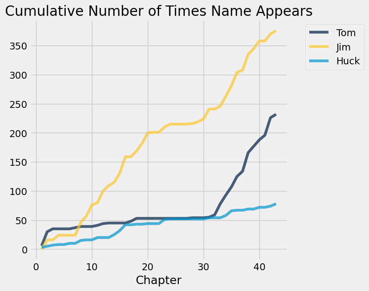

```python
original_labels =  list(counts.labels)
cumulative_values = [np.cumsum(counts.column(index)) for index in np.arange(counts.num_columns)]
cumulative_counts = (counts.with_columns(zip(original_labels, cumulative_values))
                           .with_column('Chapter', np.arange(1, 44, 1)))
cumulative_counts.plot(column_for_xticks=3)
plots.title('Cumulative Number of Times Name Appears');
```

### Little Women

Organize the Content of the Chapters of Little Women

```python
Table().with_column('Chapters', little_women_chapters)
```

| Chapters |
| --- |
| ONE PLAYING PILGRIMS "Christmas won't be Christmas wit ... |
| TWO A MERRY CHRISTMAS Jo was the first to wake in the ... |
| THREE THE LAURENCE BOY "Jo! Jo! Where are you?" crie ... |
| FOUR BURDENS "Oh, dear, how hard it does seem to take ... |
| FIVE BEING NEIGHBORLY "What in the world are you going ... |
| SIX BETH FINDS THE PALACE BEAUTIFUL The big house did ... |
| SEVEN AMY'S VALLEY OF HUMILIATION "That boy is a perfe ... |
| EIGHT JO MEETS APOLLYON "Girls, where are you going?" ... |
| NINE MEG GOES TO VANITY FAIR "I do think it was the mo ... |
| TEN THE P.C. AND P.O. As spring came on, a new set of ... |

... (37 rows omitted)

Count the names in the chapters of Little Women.

```python
people = ['Amy', 'Beth', 'Jo', 'Laurie', 'Meg']
people_counts = {pp: np.char.count(little_women_chapters, pp) for pp in people}

counts = Table().with_columns([
        'Amy', people_counts['Amy'],
        'Beth', people_counts['Beth'],
        'Jo', people_counts['Jo'],
        'Laurie', people_counts['Laurie'],
        'Meg', people_counts['Meg']
    ])
counts
```

| Amy | Beth | Jo | Laurie | Meg |
| --- | --- | --- | --- | --- |
| 23 | 26 | 44 | 0 | 26 |
| 13 | 12 | 21 | 0 | 20 |
| 2 | 2 | 62 | 16 | 36 |
| 14 | 18 | 34 | 0 | 17 |
| 6 | 14 | 55 | 35 | 13 |
| 6 | 28 | 13 | 9 | 5 |
| 27 | 5 | 9 | 7 | 5 |
| 48 | 9 | 71 | 17 | 16 |
| 3 | 5 | 21 | 24 | 71 |
| 5 | 5 | 12 | 4 | 4 |

... (37 rows omitted)

Plot the cumulative counts.

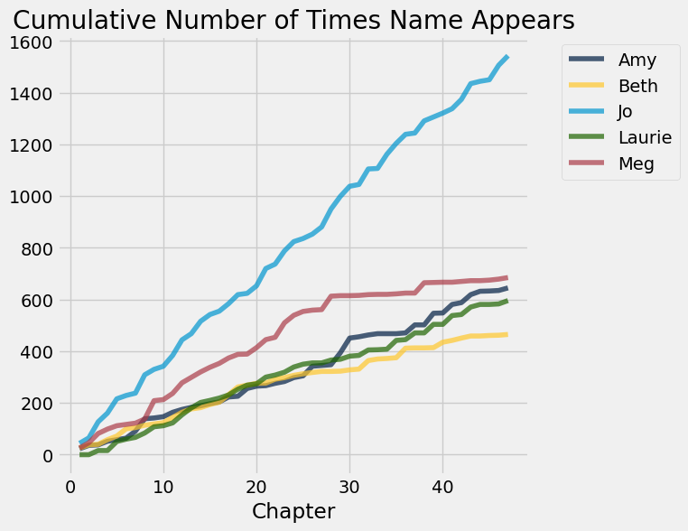

```python
original_labels =  list(counts.labels)
cumulative_values = [np.cumsum(counts.column(index)) for index in np.arange(counts.num_columns)]
cumulative_counts = (counts.with_columns(zip(original_labels, cumulative_values))
                           .with_column('Chapter', np.arange(1, 48, 1)))
cumulative_counts.plot(column_for_xticks=5)
plots.title('Cumulative Number of Times Name Appears');
```

## Exploring a Relationship

### Sentence Structure

In each chapter, count the number of all characters call this the "length" of the chapter" Also, count the number periods in each chapter.

```python
chapter_lengths_hf = [len(s) for s in huck_finn_chapters]
chapter_lengths_lw = [len(s) for s in little_women_chapters]

number_of_periods_hf = np.char.count(huck_finn_chapters, '.')
number_of_periods_lw = np.char.count(little_women_chapters, '.')

chars_periods_hf = Table().with_columns(
    'Number of Periods', number_of_periods_hf,
    'Chapter Length', chapter_lengths_hf,
    'Book', ['Huck Finn'] * len(huck_finn_chapters))

chars_periods_lw = Table().with_columns(
    'Number of Periods', number_of_periods_lw,
    'Chapter Length', chapter_lengths_lw,
    'Book', ['Little Women'] * len(little_women_chapters))
```

Notice that there is no output here. 🧐

Show the counts for Huckleberry Finn.

```python
chars_periods_hf
```

| Number of Periods | Chapter Length | Book |
| --- | --- | --- |
| 66 | 7088 | Huck Finn |
| 117 | 12113 | Huck Finn |
| 72 | 8612 | Huck Finn |
| 84 | 6892 | Huck Finn |
| 91 | 8269 | Huck Finn |
| 125 | 14672 | Huck Finn |
| 127 | 13349 | Huck Finn |
| 249 | 22483 | Huck Finn |
| 71 | 8153 | Huck Finn |
| 70 | 7109 | Huck Finn |

... (33 rows omitted)

Show the counts for Little Women.

```python
chars_periods_lw
```

| Number of Periods | Chapter Length | Book |
| --- | --- | --- |
| 189 | 21952 | Little Women |
| 188 | 22384 | Little Women |
| 231 | 20815 | Little Women |
| 195 | 25689 | Little Women |
| 255 | 23657 | Little Women |
| 140 | 14736 | Little Women |
| 131 | 14549 | Little Women |
| 214 | 22679 | Little Women |
| 337 | 34054 | Little Women |
| 185 | 19657 | Little Women |

... (37 rows omitted)

Combine the two tables into one table.

```python
chars_periods = chars_periods_hf.append(chars_periods_lw)
chars_periods
```

| Number of Periods | Chapter Length | Book |
| --- | --- | --- |
| 66 | 7088 | Huck Finn |
| 117 | 12113 | Huck Finn |
| 72 | 8612 | Huck Finn |
| 84 | 6892 | Huck Finn |
| 91 | 8269 | Huck Finn |
| 125 | 14672 | Huck Finn |
| 127 | 13349 | Huck Finn |
| 249 | 22483 | Huck Finn |
| 71 | 8153 | Huck Finn |
| 70 | 7109 | Huck Finn |

... (80 rows omitted)

### Visualizing the Relationship

Visualize the relationship betwen the length of a chapter and the number of periods in a chapter.

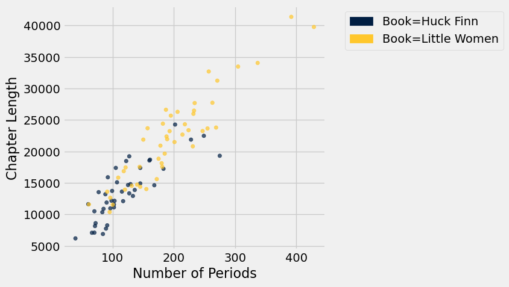

```python
chars_periods.scatter('Number of Periods', group='Book')
```

Compute the ratio of average chapter lengths to number of periods per chapter for each book.

### Recognizing a Pattern

```python
ave_num_chars_per_sentence_hf = np.average(chapter_lengths_hf) / np.average(number_of_periods_hf)
ave_num_chars_per_sentence_hf
```

```
114.9703106567047
```

```python
ave_num_chars_per_sentence_lw = np.average(chapter_lengths_lw) / np.average(number_of_periods_lw)
ave_num_chars_per_sentence_lw
```

```
112.48678462210572
```

There seems to be a consistency to sentence lengths for these two books!